# 5-1 군집화

# 5-1 군집화

## 0. 데이터셋 소개

### Gene expression

[유전자 발현](https://www.kaggle.com/datasets/crawford/gene-expression) microarray라는 측정 방법을 사용하여, 급성 골수성 백혈병 환자와 급성 림프구성 백혈병환자를 대상으로 유전자 발현도를 측정한 데이셋입니다.

원저자 논문, Molecular Classification of Cancer: Class Discovery and Class Prediction by Gene Expression Monitoring

해당 데이터는 총 7131개의 컬럼과 72개의 행을 가진 데이터로, 표본의 수보다 속성의 수가 훨씬 많은 데이터셋입니다.

주요 변수 설명

| Name | Type | Description |
| --- | --- | --- |
| patient | integer | patient no |
| cancer | binary | AML: acute myeloid leukemia ALL:acute lymphoblastic leukemia |
| train | binary | 학습 데이터 여부 |

그외 변수는 유전자의 발현도를 정수로 나타낸 변수들 입니다.

데이터 수에 비해서 입력 변수의 수가 많은 데이터셋입니다.

```r
library(readr)
library(dplyr)

# CSV 파일 읽기
df_gene <- read_csv('../data/gene.csv')
# 데이터 출력
print(head(df_gene))
```

| patient | AFFX-BioB-5_at | AFFX-BioB-M_at | AFFX-BioB-3_at | AFFX-BioC-5_at | AFFX-BioC-3_at | AFFX-BioDn-5_at | AFFX-BioDn-3_at | AFFX-CreX-5_at | AFFX-CreX-3_at | AFFX-BioB-5_st | AFFX-BioB-M_st | AFFX-BioB-3_st | AFFX-BioC-5_st | AFFX-BioC-3_st | AFFX-BioDn-5_st | AFFX-BioDn-3_st | AFFX-CreX-5_st | AFFX-CreX-3_st | hum_alu_at | AFFX-DapX-5_at | AFFX-DapX-M_at | AFFX-DapX-3_at | AFFX-LysX-5_at | AFFX-LysX-M_at | AFFX-LysX-3_at | AFFX-PheX-5_at | AFFX-PheX-M_at | AFFX-PheX-3_at | AFFX-ThrX-5_at | … |
| --- | --- | --- | --- | --- | --- | --- | --- | --- | --- | --- | --- | --- | --- | --- | --- | --- | --- | --- | --- | --- | --- | --- | --- | --- | --- | --- | --- | --- | --- | --- |
| 1 | -214 | -153 | -58 | 88 | -295 | -558 | 199 | -176 | 252 | 206 | -41 | -831 | -653 | -462 | 75 | 381 | -118 | -565 | 15091 | 7 | 311 | -231 | 21 | -107 | 165 | -78 | -204 | 29 | -61 | … |
| 2 | -139 | -73 | -1 | 283 | -264 | -400 | -330 | -168 | 101 | 74 | 19 | -743 | -239 | -83 | 182 | 164 | -141 | -423 | 11038 | 37 | 134 | -161 | -21 | -180 | 18 | -120 | -65 | 97 | 15 | … |
| 3 | -76 | -49 | -307 | 309 | -376 | -650 | 33 | -367 | 206 | -215 | 19 | -1135 | -962 | -232 | 208 | 432 | 84 | -501 | 16692 | 183 | 378 | -221 | 67 | -203 | 238 | -124 | -161 | 36 | -23 | … |
| 4 | -135 | -114 | 265 | 12 | -419 | -585 | 158 | -253 | 49 | 31 | 363 | -934 | -577 | -214 | 142 | 271 | -107 | -101 | 15763 | 45 | 268 | -27 | 43 | -52 | 247 | -116 | -208 | 22 | -10 | … |
| 5 | -106 | -125 | -76 | 168 | -230 | -284 | 4 | -122 | 70 | 252 | 155 | -471 | -490 | -184 | 32 | 213 | 1 | -260 | 18128 | -28 | 118 | -153 | -8 | -111 | 44 | -88 | -102 | 32 | 5 | … |
| 6 | -138 | -85 | 215 | 71 | -272 | -558 | 67 | -186 | 87 | 193 | 325 | -631 | -625 | -177 | -94 | 222 | -1 | -140 | 34207 | 65 | 154 | -49 | -24 | -72 | 39 | -104 | -40 | 40 | 46 | … |

## 1. 중심기반 군집화

### K-Means

K-Means 군집화는 주어진 데이터를 K개의 군집으로 그룹화하는 기법입니다.

각 군집에는 중심점(Centroid)가 있습니다. 데이터 포인트와 가까운 중심점(Centroid)을 지닌 군집에 속하게 됩니다.

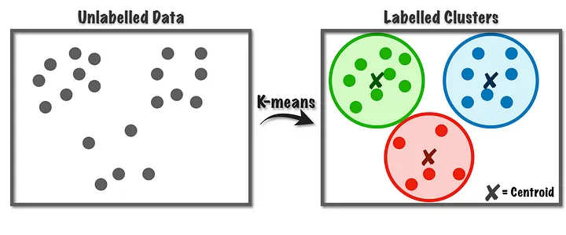

image.png

※ 이미지 출처: https://towardsdatascience.com/k-means-a-complete-introduction-1702af9cd8c

#### 학습 알고리즘

$S = {S_1, S_2, ..., S_k}$ 는 K-Means 군집에 속한 데이터 포인트의 집합일 때, 중심점은 아래와 같이 정의 됩니다.

K-means 모델의 학습은 중심점(Centroid) 과 데이터 포인트의 거리가 최소가 되는 군집화를 목표로 합니다.

> $argsmin_S \sum_{i=1}^k\sum_{x \in S_i}||x - \mu_i||^2$
1. 중심점(Centroid) 초기화

> Forgy 방법: k개의 서로 다른 임의의 데이터 포인트들을 군집의 중심점(Centroid)으로 초기화합니다.

> 랜덤 분할 방법: 각각의 데이터 포인트들을 임의의 군집으로 할당합니다.
2. 할당 단계(Allocation Step): 데이터 포인트에서 가장 가까운 중심점의 군집에 할당합니다.
3. 업데이트 단계(Update Step): 군집에 할당된 데이터 포인트의 중심을 구하여 중심점(Centroid)를 업데이트 합니다..
4. 종료 조건을 확인하고 만족하지 않으면 2번 단계로 이동합니다.
5. 군집의 성능을 측정하고 중심점을 저장합니다.
6. 군집화 반복 조건을 확인하고 반복수를 충족하지 않으면 1번 부터 수행합니다.

> K-Means 군집화는 초기 중심점에 따라 성능이 다릅니다. 초기점을 달리하여 군집화를 수행하여 가장 좋은 결과를 취하기도 합니다.
7. 가장 좋은 성능을 보인 군집화 결과를 최종 군집화 모델로 선정합니다.

**[Ex.1]**

K-Means 군집화를 이 데이터셋으로 수행을 하고, 결과를 시각화시켜 봅니다.

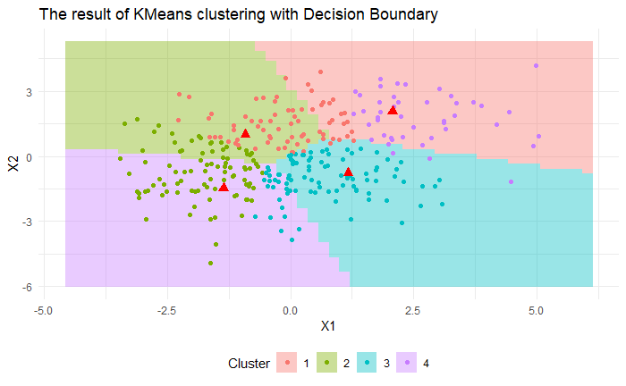

```r
# 필요한 라이브러리 로드
library(ggplot2)
library(gridExtra)

# 데이터 생성
set.seed(123)
X <- as.data.frame(MASS::mvrnorm(300, mu = c(0, 0), Sigma = matrix(c(3, 1, 1, 3), 2)))
colnames(X) <- c("X1", "X2")
X$cluster <- kmeans(X, centers = 4)$cluster

# KMeans 모델 생성 및 학습
kmeans_model <- kmeans(X[, 1:2], centers = 4)

# 결정 경계를 그리기 위한 메쉬그리드 생성
x_min <- min(X$X1) - 1
x_max <- max(X$X1) + 1
y_min <- min(X$X2) - 1
y_max <- max(X$X2) + 1
xx <- seq(x_min, x_max, length.out = 50)
yy <- seq(y_min, y_max, length.out = 50)
grid <- expand.grid(X1 = xx, X2 = yy)

# 각 점에 대한 예측값 계산 함수
predict_kmeans <- function(model, newdata) {
  centers <- as.matrix(model$centers)
  newdata <- as.matrix(newdata)
  dists <- as.matrix(dist(rbind(centers, newdata)))[-seq_len(nrow(centers)), seq_len(nrow(centers))]
  apply(dists, 1, which.min)
}

# 메쉬그리드에 대해 예측값 계산
grid$cluster <- predict_kmeans(kmeans_model, grid)

# 예측 결과를 시각화
ggplot() +
  geom_tile(data = grid, aes(x = X1, y = X2, fill = as.factor(cluster)), alpha = 0.4) +
  geom_point(data = X, aes(x = X1, y = X2, color = as.factor(cluster)), size = 1.5) +
  geom_point(data = as.data.frame(kmeans_model$centers), aes(x = X1, y = X2), color = "red", size = 3, shape = 17) +
  labs(title = "The result of KMeans clustering with Decision Boundary", x = "X1", y = "X2") +
  theme_minimal() +
  scale_fill_discrete(name = "Cluster") +
  scale_color_discrete(name = "Cluster") +
  theme(legend.position = "bottom")
```

### K-Medoids

K-Means와 달리, 군집의 대표점을 군집의 중심점(centroid)로 하는 반면 K-Medoid는 가장 중심에 위치한 데이터 포인트(중심, medoid)입니다.

K-Means는 유클리디언 거리를 사용하여 거리 측정을 하는 반면 K-Medoid는 맨하탄 거리 등 다른 거리 측정 방법을 사용합니다.

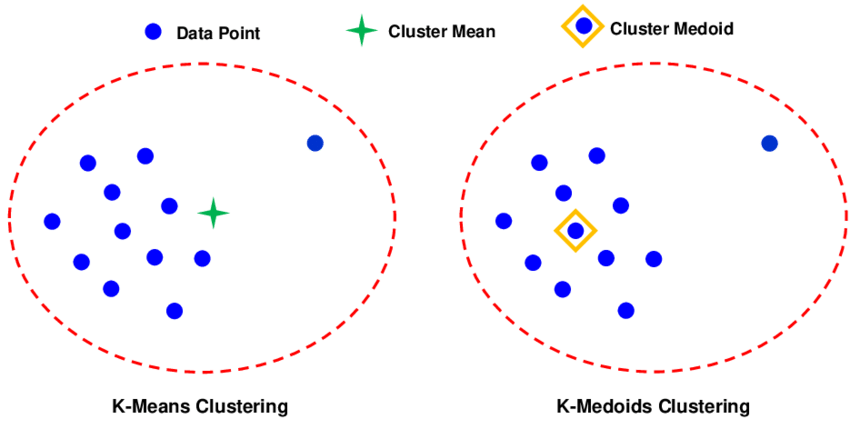

image.png

※ 이미지 출처: https://www.researchgate.net/figure/The-graphical-representation-of-the-difference-between-the-k-means-and-k-medoids_fig1_342871651

#### 학습 알고리즘

1. 대표(Medoid) 초기화: 임의의 K개의 데이터 포인트를 선정하여 각 군집의 Medoid로 할당합니다.
2. 할당 단계(Allocation Step): 각 데이터 포인트의 소속 군집을 가장 거리가 인접한 대표(Medoid)점에 해당하는 군집으로 설정합니다.
3. 업데이트 단계(Update Step): 각 군집의 대표점을 군집내의 다른 데이터 포인트와의 거리의 합이 최소인 데이터 포인트로 변경합니다.
4. 종료 조건을 확인하고 만족하지 않으면 2번 단계로 이동합니다.
5. 군집의 성능 측정하고 중심점을 저장합니다.
6. 군집화 반복 조건을 확인하고 반복수를 충족하지 않으면 1번 부터 수행합니다.

> K-Means 군집화는 초기 중심점에 따라 성능이 다릅니다. 초기점을 달리하여 군집화를 수행하여 가장 좋은 결과를 취하기도 합니다.
7. 가장 좋은 성능을 보인 군집화 결과를 최종 군집화 모델로 선정합니다.

#### K-Means와의 비교

- K-Means에 비해 이상치에 덜 민감합니다.
- 학습시 대표(Medoid)를 구하는 과정에서 추가적인 계산 리소스가 필요합니다.

**[Ex.2]**

[Ex.1] 데이터셋을 K-Medoids 군집화를 이 데이터셋으로 수행을 하고, 결과를 시각화시켜 봅니다.

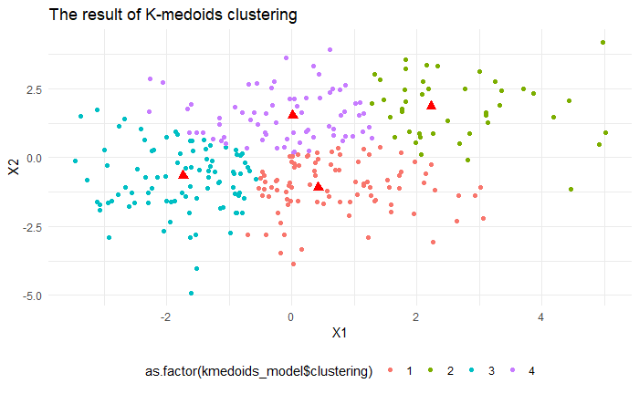

```r
library(cluster)

# K-medoids 모델 생성 및 학습
kmedoids_model <- pam(X, k = 4)


# 각 점에 대한 예측값 계산 함수
predict_kmedoids <- function(model, newdata) {
  dists <- as.matrix(dist(rbind(model$medoids, newdata)))
  dists <- dists[-seq_len(nrow(model$medoids)), seq_len(nrow(model$medoids))]
  apply(dists, 1, which.min)
}

# 예측 결과를 시각화
ggplot() +
  geom_point(data = X, aes(x = X1, y = X2, color = as.factor(kmedoids_model$clustering)), size = 1.5) +
  geom_point(data = as.data.frame(kmedoids_model$medoids), aes(x = X1, y = X2), color = "red", size = 3, shape = 17) +
  labs(title = "The result of K-medoids clustering", x = "X1", y = "X2") +
  theme_minimal() +
  theme(legend.position = "bottom")
```

## 2. 계층적 군집화 (Hierarchical Clustering)

모든 데이터 포인트 각각이 하나씩 구성된 군집 상태에서 시작하여,

가장 유사도가 높은 군집 쌍(pair)을 우선하여 반복적으로 병합해 가는 방식의 군집화 모델입니다.

모든 데이터가 하나의 군집으로 결합 되면 나무와 같은 형태의 구조를 가집니다.

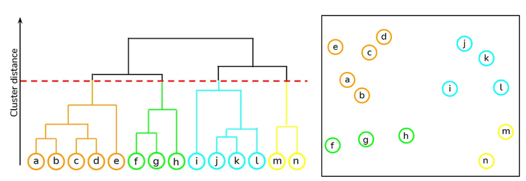

image.png

※ 이미지 출처:https://towardsdatascience.com/hierarchical-clustering-explained-e59b13846da8

### 병합 군집화(Agglomerative Clustering)

#### 군집의 연결(linkage) 기준 측정

군집 A, B의 결합 기준 측정하는 방법입니다.

d(a, b): 데이터 포인트 a와 b의 거리 입니다.

1. 단일 연결(single linkage): $min_{a \in A, b\in B} d(a, b)$
2. 완전 연결(complete linkage): $max_{a \in A, b\in B} d(a, b)$
3. 평균 연결(average linkage): $\frac{1}{|A||B|}\sum_{a \in A}\sum_{b \in B} d(a, b)$

> $|A|$: A의 원소수, $|B|$: B의 원소수
4. 워드 연결(ward linkage): 분산의 증가량이 최소화하는 방향으로 연결합니다.

> Minimum Increase in Sum of Square(MISSQ): $\sum_{x \in A \cup B} ||x - \mu_{A \cup B}||^2 - \sum_{x \in A} ||x - \mu_A||^2 - \sum_{x \in B} ||x - \mu_B||^2$

> Minimum Increase in Variance(MIVAR): $Var(A \cup B) - Var(A) - Var(B)$

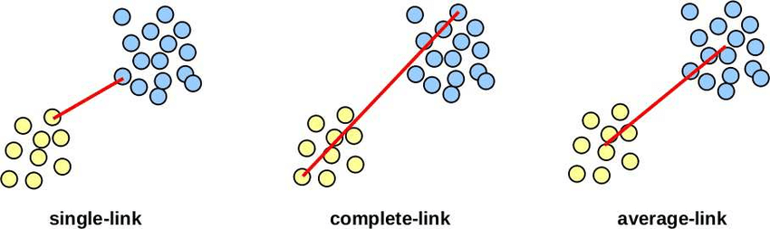

image.png

※ 이미지 출처: https://www.researchgate.net/figure/The-three-linkage-types-of-hierarchical-clustering-single-link-complete-link-and_fig57_281014334

**[Ex.3]**

df_gene에서 train, cancer를 제외하고 표준화를 합니다.

표준화한 데이터프레임으로 평균 연결(average linkage) 방법으로 병합 군집화합니다.

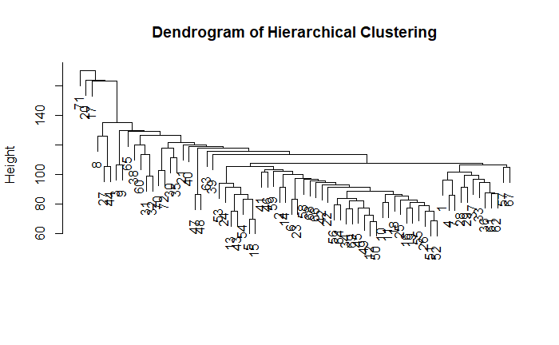

```r
# 필요한 라이브러리 로드
library(stats)
library(ggplot2)

# 표준화 수행
X_cols <- setdiff(names(df_gene), c('train', 'cancer'))
df_gene_std <- as.data.frame(scale(df_gene[, X_cols]))

# 데이터 전처리
# df_gene_std 데이터프레임이 이미 존재한다고 가정합니다.
# Euclidean 거리를 사용하여 거리 행렬을 생성합니다.
dist_matrix <- dist(df_gene_std, method = "euclidean")

# average linkage 방법을 사용하여 계층적 군집화 수행
hclust_result <- hclust(dist_matrix, method = "average")

# 덴드로그램 시각화
plot(hclust_result, main = "Dendrogram of Hierarchical Clustering", xlab = "", sub = "")
```

## 3. 밀도 기반 군집화(Density-based Clustering)

데이터 포인트들의 밀도를 기반으로 군집을 생성합니다.

### DBSCAN(Density-Based Spatial Clustering of Applications with Noise)

#### DBSCAN에서 데이터 포인트 분류 3가지

- 핵심 포인트(core point): 주변 영역 내에 최소 n개의 이웃 데이터 포인트가 존재하는 데이터 포인트
- 경계 포인트(border point): 주변 영역 내에 n개 만큼 데이터 포인트가 존재하지 않지만 핵심 포인트의 영역안에 있는 데이터 포인트
- 잡음 포인트(noise point): 주변 영역 내에 n개 만큼의 데이터 포인트도 존재하지 않고, 핵심 포인트의 영역안에 있지 않는 데이터 포인트

#### DBSCAN의 주요 요소

- $\epsilon$ 반경: 데이터 포인트의 주변 영역 반경
- 최소 이웃수: 핵심 포인트가 되기 위한 입실론 반경 내의 최소 데이터 포인트 수

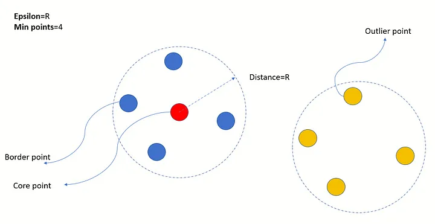

image.png

※ 이미지 출처: https://medium.com/@saurabh.dasgupta1/understanding-the-epsilon-parameter-of-dbscan-clustering-algorithm-fe85669e0cae

#### 군집 형성의 기준

상호 밀도연결된(density-connected) 모든 데이터 포인트들은 동일한 군집을 형성합니다.

> 도달가능성(Reachability): 핵심 포인트에서 입실론 반경내의 다른 포인트는 도달 가능성이 있습니다.. 비핵심 포인트에서 다른 포인트로는 도달가능성이 없습니다.

> 밀도연결된(density-connected): p와 q에 모두 도달이 가능한 데이터 포인트 o가 존재하면 p와 q는 밀도 연결된 상태입니다.

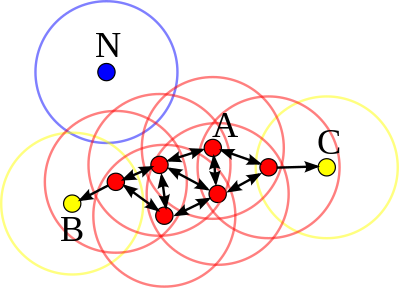

image.png

※ 이미지 출처: https://en.wikipedia.org/wiki/DBSCAN

#### 학습 알고리즘

1. 초기화 합니다.
- 데이터 포인트의 군집 상태를 나타내는 영역 label을 정의하고, 모두 상태값을 미정의(undefined)로 초기화합니다.

> label은 미정의(undefined), 잡음 포인트(noise point), 군집 번호를 나타냅니다.
- C = 0 ← 현재 형성 중인 군집 번호입니다.
- 데이터 포인트마다 $\epsilon$ 반경 이내의 데이터 포인트를 구합니다.
2. label이 undefined 상태인 임의의 데이터 포인트 P를 선택합니다. 선택할 데이터 포인트가 없으면 종료합니다.
3. P의 최소 이웃 수 보다 작으면, label에 noise point라고 표시하고 2단계로 이동합니다.
4. C = C + 1, label(P) = C 로 설정합니다.
5. P에서 도달 가능한 데이터 포인트들을 리스트 S로 정의합니다.
6. S의 모든 데이터 포인트의 label을 C로 저장합니다.
7. S에 데이터 포인트가 없으면 2단계로 이동하고, 아니면 S에서 데이터 포인트 Q를 하나 꺼냅니다.
8. Q의 label이 noise point이면 Q의 label을 C로 설정합니다. Q의 label이 미정의(undefined)가 아니면 7단계로 이동합니다.
9. Q의 label을 C로 설정하고, Q가 핵심 포인트(core point)이면 Q의 이웃 데이터 포인트들을 S에 추가하고 7 단계로 이동합니다.

**[Ex 4]**

2개의 고리 모양을 지닌 2 차원 데이터셋을 만들어,

DBSCAN으로 2개의 군집으로 나누어 봅니다.

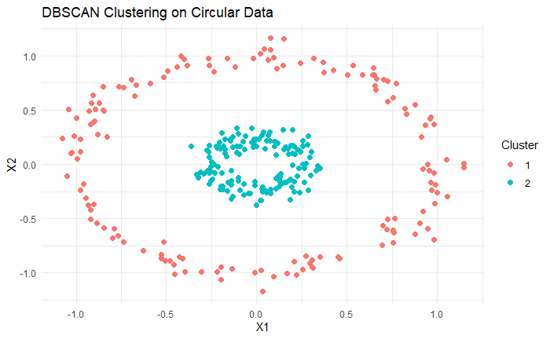

```r
# 필요한 라이브러리 로드
library(dbscan)
library(mlbench)
library(ggplot2)

# 고리 모양의 두 개의 군집 형태의 데이터 생성
set.seed(123)
n_samples <- 300
noise <- 0.07
factor <- 0.25

# 원형 데이터 생성 함수 정의
make_circles <- function(n_samples, factor, noise) {
  n <- n_samples / 2
  theta <- runif(n, 0, 2 * pi)
  r1 <- rep(1, n)
  r2 <- rep(factor, n)
  circle1 <- data.frame(x = r1 * cos(theta) + rnorm(n, sd = noise),
                        y = r1 * sin(theta) + rnorm(n, sd = noise))
  circle2 <- data.frame(x = r2 * cos(theta) + rnorm(n, sd = noise),
                        y = r2 * sin(theta) + rnorm(n, sd = noise))
  return(rbind(circle1, circle2))
}

# 데이터 생성
df <- make_circles(n_samples, factor, noise)

# DBSCAN 알고리즘을 사용하여 클러스터링 수행
db <- dbscan(df, eps = 0.25, minPts = 5)

# 클러스터링 결과를 데이터프레임에 추가
df$cluster <- as.factor(db$cluster)

# 클러스터링 결과 시각화
ggplot(df, aes(x = x, y = y, color = cluster)) +
  geom_point(size = 2) +
  labs(title = "DBSCAN Clustering on Circular Data",
       x = "X1",
       y = "X2") +
  scale_color_discrete(name = "Cluster") +
  theme_minimal()
```

## 4. 혼합 모델 기반 군집화(Mixture Model-Based Clustering)

데이터가 여러 개의 확률 분포의 혼합으로 이루졌다고 가정하고 군집을 형성합니다.

### 가우시안 혼합 모델(Gaussian Mixture Model)

- 가우시안 혼합 모델은 데이터의 분포를 여러 개의 가우시안 확률 모델의 선형 결합으로 나타냅니다.
- 데이터 포인트가 속할 확률이 가장 높은 확률 모델이 데이터 포인트의 군집이 됩니다.
- K-Means 모델 처럼 초기 모수에 따라 성능의 차이가 납니다. 여러 번의 시행 중에 가장 좋은 결과를 보이는 모델을 선정합니다.

#### 학습 알고리즘

- EM 알고리즘을 사용하여 학습합니다.

5-3 의 EM 알고리즘을 다변량 가우시안 분포 버젼으로 일반화 합니다.

$\theta = (\mu, \Sigma, \tau)$

> $X_i | Z_i = 1 \sim N(\mu'_1, \Sigma'_1)$, … , $X_i | Z_i = j \sim N(\mu'_j, \Sigma'_j)$

> $P(Z = 1) = \tau'_1$, … ,$P(Z = i) = \tau'_i$,

$T_{j,i} = \frac{P(X_i = x_i | Z_i = j; \theta') P(Z=j)}{\sum_{k = 1}^CP(X_i = x_i | Z_i = k; \theta') P(Z = k)}$

$\tau_j = \frac{1}{n}\sum_{i=1}^n T_{j,i}$,

$\mu_j = \frac{\sum_{i=1}^nT_{j,i}x_i}{\sum_{i=1}^n T_{j,i}}$,

$\Sigma_j = \frac{\sum_{i=1}^nT_{j,i}(x_i - \mu_j)^T(x_i - \mu_j)}{\sum_{i=1}^n T_{j,i}}$

**[Ex 5]**

3개 다변량 가우시안 분포가 합쳐진 2차원 데이터셋을 만들어서,

가우시안 혼합 모델을 EM 알고리즘으로 학습하고, 이 결과를 출력해봅니다.

```r
# 필요한 라이브러리 로드
library(mclust)
library(ggplot2)

# 데이터 생성
set.seed(123)
n <- 300

# 3개의 군집을 만듭니다.
mu1 <- c(2, 2)
mu2 <- c(-2, -2)
mu3 <- c(2, -2)

sigma1 <- matrix(c(0.3, 0.2, 0.2, 0.3), 2, 2)
sigma2 <- matrix(c(0.3, -0.2, -0.2, 0.3), 2, 2)
sigma3 <- matrix(c(0.3, 0.2, 0.2, 0.3), 2, 2)

cluster1 <- MASS::mvrnorm(n = n, mu = mu1, Sigma = sigma1)
cluster2 <- MASS::mvrnorm(n = n, mu = mu2, Sigma = sigma2)
cluster3 <- MASS::mvrnorm(n = n, mu = mu3, Sigma = sigma3)

df <- rbind(cluster1, cluster2, cluster3)
df <- data.frame(x = df[, 1], y = df[, 2])

# GMM을 사용하여 군집화
gmm <- Mclust(df, G = 3)
```

```
fitting ...
```

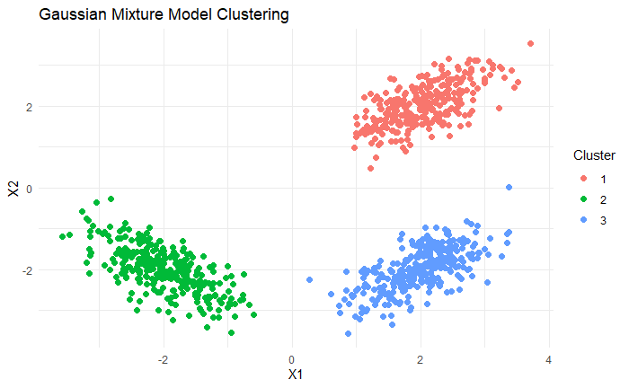

```r
# 군집 결과를 데이터프레임에 추가
df$cluster <- as.factor(gmm$classification)

# 군집 결과 시각화
ggplot(df, aes(x = x, y = y, color = cluster)) +
  geom_point(size = 2) +
  labs(title = "Gaussian Mixture Model Clustering",
       x = "X1",
       y = "X2") +
  scale_color_discrete(name = "Cluster") +
  theme_minimal()
```